# Analyze WeRateDogs Tweets

Mercy Nyambura Kariuki

## Introduction

This report communicates the insights and displays the visualizations produced from my wrangled data about WeRateDogs Twitter achive taken from 3 different sources.

**About WE RATE DOGS**

The dataset used for wrangling (and analyzing and visualizing) is the tweet archive of Twitter user @dog_rates, also known as WeRateDogs. WeRateDogs is a Twitter account that rates people's dogs with a humorous comment about the dog. These ratings almost always have a denominator of 10. The numerators, almost always greater than 10. 11/10, 12/10, 13/10, etc. Why? Because "they're good dogs Brent." WeRateDogs has over 4 million followers and has received international media coverage.

WeRateDogs downloaded their Twitter archive and sent it to Udacity via email exclusively for student like us to use in this project. This archive contains basic tweet data (tweet ID, timestamp, text, etc.) for all 5000+ of their tweets as they stood on August 1, 2017.

### Insights

**Insight 1:** Which breed is the most common in this twitter archive?

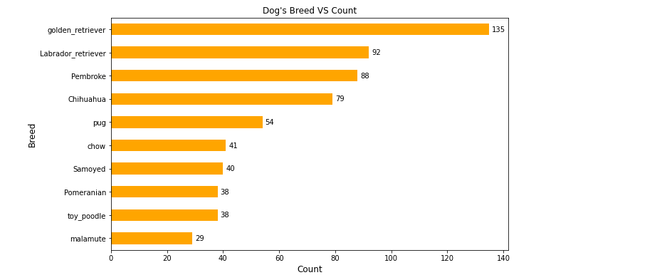

The most common breed in this twitter archive is the Golden Retrieverwhich appears 135 times. This followed by the Labrador Retriever followed by Pembroke

**Insight 2:** Which breed has the highest rating average?

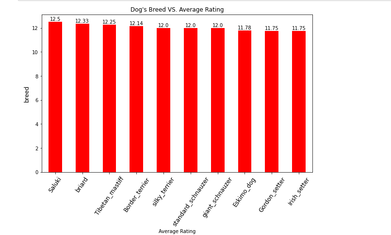

The rating have a slight ifference. However, the highest breed with an average rating is the Saluki.

**Insight 3:** Which dog breed has the highest average number of tweets and favorites?

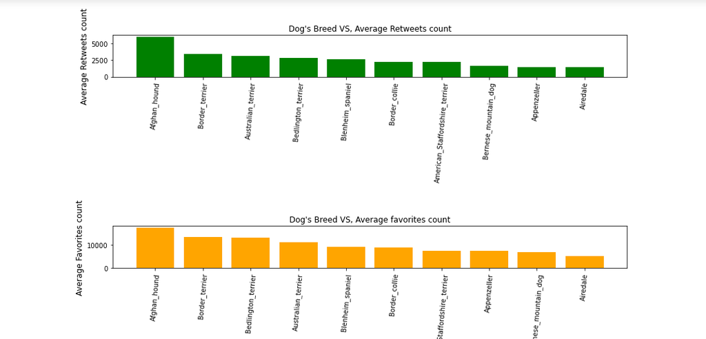

The Afghan Hound has the highest retweets an favorites in this twitter archive followed by Border Terrier in both accounts